# [Respostas] - Lista_Atividades_Regression.pdf

## 1. Exercício 1 (Regressão Linear Simples)

> Considere o conjunto de dados data.txt, que organiza em um arquivo de texto dados sobre os lucros de diversas empresas e a população da cidade na qual a respectiva empresa se localiza. Nosso objetivo, é conduzir uma análise de regressão linear simples para que possamos construir um modelo que busque explicar os dados que temos acesso. A variável explanatória, i.e., feature ou variável de entrada, é o conjunto de dados populacionais das cidades (baseados em 10,000 habitantes) em uma região analisada nos USA, enquanto a variável dependente, ou de saída, consiste nos lucros declarados pelas empresas (baseados em uma escala de $10,000 dólares) que atuam nas cidades da região analisada. De forma analítica, a função hipótese candidata no caso do modelo de regressão linear é dada por: hˆ θ (x) = θ0 +θ1x1 Considere a função custo retratada pelo erro quadrático médio para construção do modelo de ML. Abaixo, seguem os itens que devemos solucionar neste desenvolvimento, visando alcançar o objetivo do exercício:

> Faça a análise exploratória das variáveis de entrada e saída. Utilize os nomes population e profit.

```r
data <- read.csv("data.txt", sep=",", header=F, col.names = c("population", "profit"))
summary(data)
```

```
##    population         profit
##  Min.   : 5.027   Min.   :-2.681
##  1st Qu.: 5.708   1st Qu.: 1.987
##  Median : 6.589   Median : 4.562
##  Mean   : 8.160   Mean   : 5.839
##  3rd Qu.: 8.578   3rd Qu.: 7.047
##  Max.   :22.203   Max.   :24.147
```

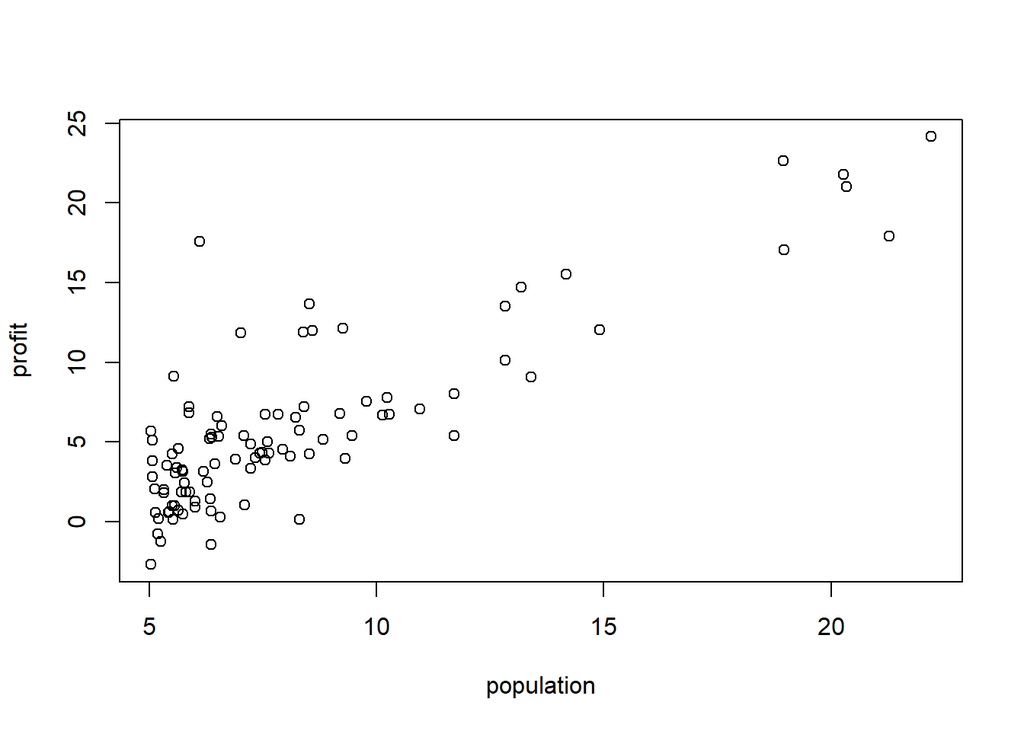

```r
plot(profit~population, data=data)
```

> 2) Construa e treine o modelo preditivo de ML baseado em regressão linear simples.

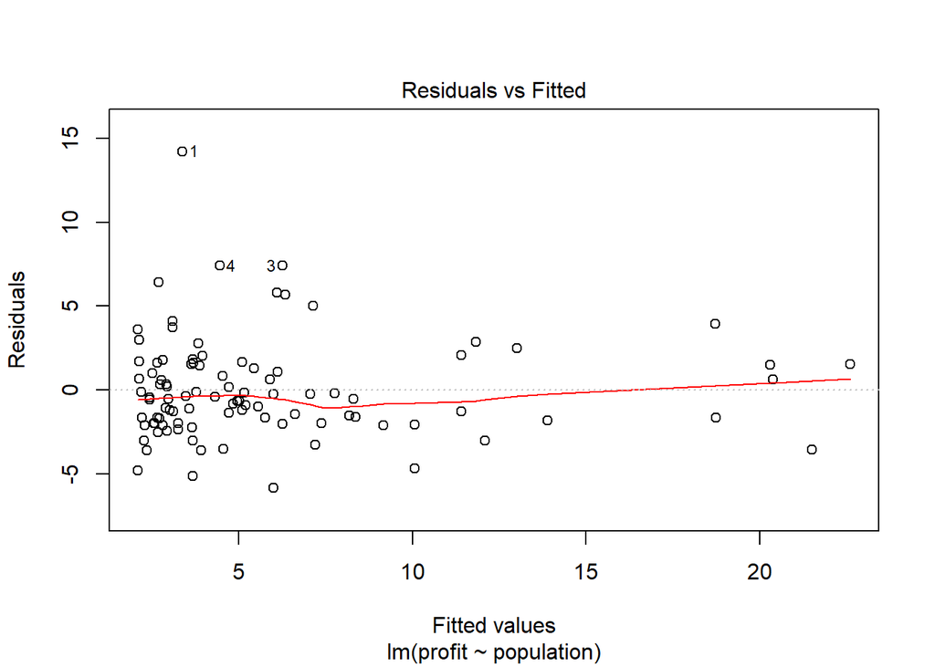

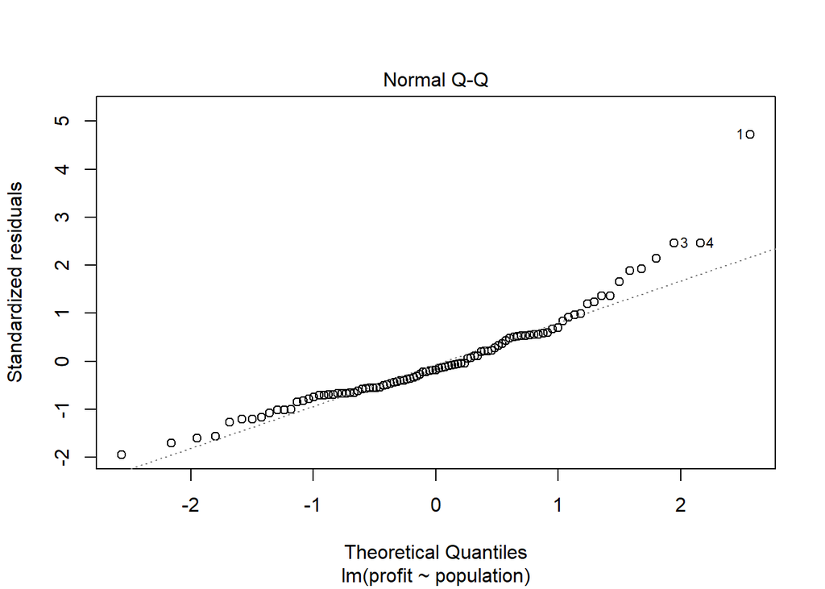

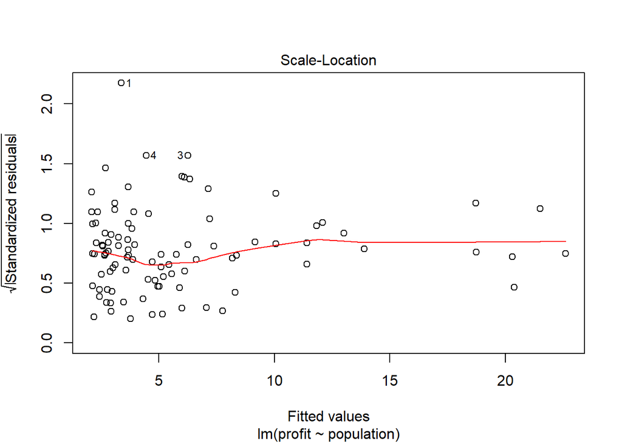

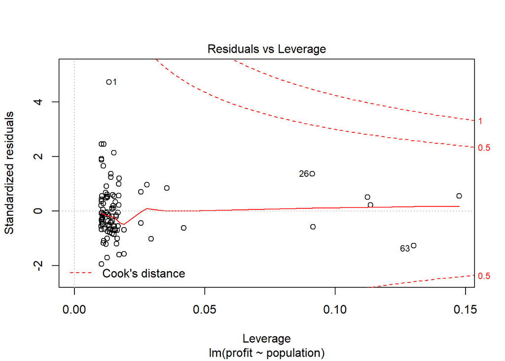

```r
data.m1 <- lm(profit~population, data=data)
plot(data.m1)
```

```r
#plot(profit~population, data=data) + abline(data.m1, col="blue")
```

> 3. Realize as predições do modelo sobre os dados de treinamento e calcule a média de seus resíduos.

```r
summary(data.m1)
```

```
##
## Call:
## lm(formula = profit ~ population, data = data)
##
## Residuals:
##     Min      1Q  Median      3Q     Max
## -5.8540 -1.9686 -0.5407  1.5360 14.1982
##
## Coefficients:
##             Estimate Std. Error t value Pr(>|t|)
## (Intercept) -3.89578    0.71948  -5.415 4.61e-07 ***
## population   1.19303    0.07974  14.961  < 2e-16 ***
## ---
## Signif. codes:  0 '***' 0.001 '**' 0.01 '*' 0.05 '.' 0.1 ' ' 1
##
## Residual standard error: 3.024 on 95 degrees of freedom
## Multiple R-squared:  0.702,  Adjusted R-squared:  0.6989
## F-statistic: 223.8 on 1 and 95 DF,  p-value: < 2.2e-16
```

```r
predict(data.m1)
```

```
##         1         2         3         4         5         6         7         8
##  3.393774  2.698951  6.267196  4.459272  3.095158  6.105301  5.023816  6.338181
##         9        10        11        12        13        14        15        16
##  3.842474  2.134527  2.917276 13.002348  2.945074  6.135723  2.833764  2.522024
##        17        18        19        20        21        22        23        24
##  3.698355  2.224601  3.774948  4.539921  3.488024 20.287011  2.654093  3.651469
##        25        26        27        28        29        30        31        32
##  2.743332 18.706242 11.408455  9.176289 11.823630 22.593145  2.370509  3.965595
##        33        34        35        36        37        38        39        40
##  7.137633  3.133335  5.900338  5.569032  5.762900  2.792724 11.417999  3.684039
##        41        42        43        44        45        46        47        48
##  2.554833  4.315273 10.072257  2.992437  5.439349  4.566526  2.153138  3.025485
##        49        50        51        52        53        54        55        56
## 10.062713  2.715534  5.099931  2.436484  4.961182  5.174973  3.659463  3.690601
##        57        58        59        60        61        62        63        64
##  3.589551  2.832571  7.211601  7.382682  6.633218  2.283298 21.490782 13.889965
##        65        66        67        68        69        70        71        72
## 18.722944  4.715775  6.000553  8.316112  2.665188 20.371716  8.196808  4.854524
##        73        74        75        76        77        78        79        80
##  3.269818  4.724961  2.101480  3.916084  5.098023  2.112933  8.361447  2.197877
##        81        82        83        84        85        86        87        88
##  2.939347  2.294155  3.686783  7.758607  3.877907  6.265525  7.056507  3.264807
##        89        90        91        92        93        94        95        96
##  2.690242  2.140254  2.913697  5.214940  3.108162  2.433740  5.998524 12.083712
##        97
##  2.590624
```

> 4. Qual seria a predição de lucro de uma empresa, considerando uma cidade na região analisadas que conta com 100,000 habitantes?

```r
data.new <- data.frame("population"=c(10))

result <- predict(data.m1, data.new)

result * 10000
```

```
##        1
## 80345.56
```

> 5. Implemente o algoritmo do gradiente descendente.

```r
epoch <- 5000

y_hat <- function(x, w0, w1) {
  value = w0 + w1 * x;
  value;
}

MSE <- function(X, y, w0, w1) {
  custo = 0;
  m = as.double(length(X))
  for (i in 1: m) {
    result = (y_hat(X[i], w0, w1) - y[i]) ^ 2
    custo = custo + result
  }
  custo / m
}


gradient_descent_step <- function (w0, w1, X, y, alpha) {
  erro_w0 = 0
  erro_w1 = 0
  m =  as.double(length(X))

  for (i in 1:length(X)) {
    erro_w0 = erro_w0 + (y_hat(X[i], w0, w1) - y[i]);
    erro_w1 = erro_w1 + ((y_hat(X[i], w0, w1) - y[i]) * X[i]);
  }
  new_w0 = w0 - alpha * (1/m) * erro_w0;
  new_w1 = w1 - alpha * (1/m) * erro_w1;

  c(new_w0, new_w1)
}


custo <- rep(0, times=epoch)

values = c(0.1, 0.1)
alpha <- 0.01

for (i in 1:epoch) {
  values <- gradient_descent_step(values[1], values[2], data$population, data$profit , alpha)
  custo[i] = MSE(data$population, data$profit, values[1], values[2])
}

print(values)
```

```
## [1] -3.895290  1.192984
```

```r
result = y_hat(10, values[1], values[2]) * 10000
print(result)
```

```
## [1] 80345.53
```

MSE do Gradiente descendente. importante notar que apartir de 2000 iterações o erro praticamente não diminui.

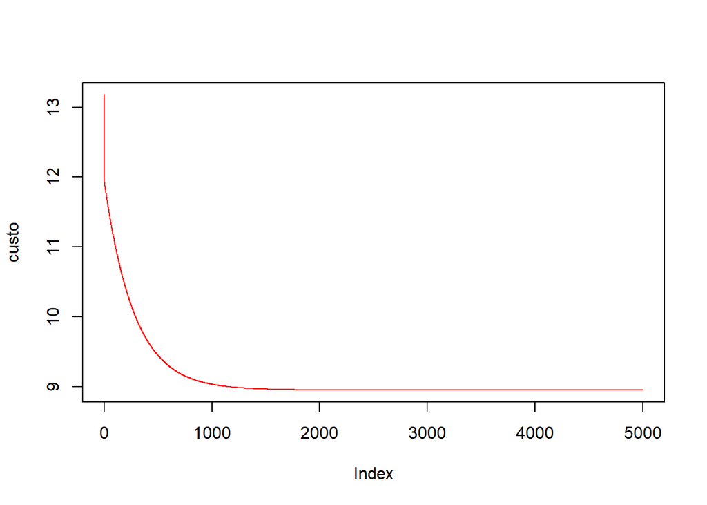

```r
plot(custo, type="l", col="red")
```

> 6. Solucione o problema de regressão linear com as equações normais e faça um comparativo.

```r
x = data$population
y = data$profit

size_data = dim(data)
ones_data = replicate(size_data[1], 1)

X = data.frame(ones_data, x)
X = as.matrix(X)

result = solve(t(X) %*% X) %*% (t(X) %*% y)


print(sprintf("theta0: %f | theta1: %f", result[1], result[2]))
```

```
## [1] "theta0: -3.895781 | theta1: 1.193034"
```

> 7. Compare os resultados do modelo construído com os parâmetros obtidos com o algoritmo GD

Os resultados obtidos para os parametros theta0 e theta1 foram os mesmos, porém o caminho foi difente.